# HW4

Anish Mohan

October 18, 2015

1. Q1
- 1a.

  ```r
    library(ISLR)
    attach(Default)
    set.seed(2)
    glm.fit=glm(default~income+balance, family=binomial)
  ```

- 1b.

  ```r
    train=sample(10000,6000)
    train_default=(Default[train,])
    test_default=(Default[-train,])
    glm.fit=glm(default~income+balance, train_default,family=binomial)
    glm.probs=predict(glm.fit,test_default,type="response")
    glm.pred=rep("No",4000)
    glm.pred[glm.probs>0.5]="Yes"
    table(glm.pred,test_default$default)
  ```

  ```
  ##
  ## glm.pred   No  Yes
  ##      No  3852   95
  ##      Yes   14   39
  ```

  ```r
    print(paste0("Error rate = ", mean(glm.pred!=test_default$default)*100,"%"))
  ```

  ```
  ## [1] "Error rate = 2.725%"
  ```

- 1c.

  ```r
    train=sample(10000,5000)
    train_default=(Default[train,])
    test_default=(Default[-train,])
    glm.fit=glm(default~income+balance, train_default,family=binomial)
    glm.probs=predict(glm.fit,test_default,type="response")
    glm.pred=rep("No",5000)
    glm.pred[glm.probs>0.5]="Yes"
    table(glm.pred,test_default$default)
  ```

  ```
  ##
  ## glm.pred   No  Yes
  ##      No  4823  105
  ##      Yes   21   51
  ```

  ```r
    print(paste0("Error rate = ", mean(glm.pred!=test_default$default)*100,"%"))
  ```

  ```
  ## [1] "Error rate = 2.52%"
  ```

  ```r
    train=sample(10000,500)
    train_default=(Default[train,])
    test_default=(Default[-train,])
    glm.fit=glm(default~income+balance, train_default,family=binomial)
    glm.probs=predict(glm.fit,test_default,type="response")
    glm.pred=rep("No",9500)
    glm.pred[glm.probs>0.5]="Yes"
    table(glm.pred,test_default$default)
  ```

  ```
  ##
  ## glm.pred   No  Yes
  ##      No  9141  223
  ##      Yes   45   91
  ```

  ```r
    print(paste0("Error rate = ", mean(glm.pred!=test_default$default)*100,"%"))
  ```

  ```
  ## [1] "Error rate = 2.82105263157895%"
  ```

  ```r
    train=sample(10000,8000)
    train_default=(Default[train,])
    test_default=(Default[-train,])
    glm.fit=glm(default~income+balance, train_default,family=binomial)
    glm.probs=predict(glm.fit,test_default,type="response")
    glm.pred=rep("No",2000)
    glm.pred[glm.probs>0.5]="Yes"
    table(glm.pred,test_default$default)
  ```

  ```
  ##
  ## glm.pred   No  Yes
  ##      No  1937   31
  ##      Yes    8   24
  ```

  ```r
    print(paste0("Error rate = ", mean(glm.pred!=test_default$default)*100,"%"))
  ```

  ```
  ## [1] "Error rate = 1.95%"
  ```

  - Fairly low error rates are observed even when using only 5% of given data for training the model. Logistic regression captures the underlying distribution well and is able to predict with a good accuracy.
- 1d.

  ```r
  train=sample(10000,5000)
  train_default=(Default[train,])
  test_default=(Default[-train,])
  glm.fit=glm(default~income+balance+student, train_default,family=binomial)
  glm.probs=predict(glm.fit,test_default,type="response")
  glm.pred=rep("No",5000)
  glm.pred[glm.probs>0.5]="Yes"
  table(glm.pred,test_default$default)
  ```

  ```
  ##
  ## glm.pred   No  Yes
  ##      No  4814  108
  ##      Yes   23   55
  ```

  ```r
  print(paste0("Error rate = ", mean(glm.pred!=test_default$default)*100,"%"))
  ```

  ```
  ## [1] "Error rate = 2.62%"
  ```

  - Adding Student does not seem to a significant impact in reducing the test error.

# Q2

- 2a.

  ```r
     set.seed(1)
    glm.fit=glm(default~income+balance,Default,family=binomial)
    summary(glm.fit)
  ```

  ```
  ##
  ## Call:
  ## glm(formula = default ~ income + balance, family = binomial,
  ##     data = Default)
  ##
  ## Deviance Residuals:
  ##     Min       1Q   Median       3Q      Max
  ## -2.4725  -0.1444  -0.0574  -0.0211   3.7245
  ##
  ## Coefficients:
  ##               Estimate Std. Error z value Pr(>|z|)
  ## (Intercept) -1.154e+01  4.348e-01 -26.545  < 2e-16 ***
  ## income       2.081e-05  4.985e-06   4.174 2.99e-05 ***
  ## balance      5.647e-03  2.274e-04  24.836  < 2e-16 ***
  ## ---
  ## Signif. codes:  0 '***' 0.001 '**' 0.01 '*' 0.05 '.' 0.1 ' ' 1
  ##
  ## (Dispersion parameter for binomial family taken to be 1)
  ##
  ##     Null deviance: 2920.6  on 9999  degrees of freedom
  ## Residual deviance: 1579.0  on 9997  degrees of freedom
  ## AIC: 1585
  ##
  ## Number of Fisher Scoring iterations: 8
  ```

- 2b.

  ```r
  boot.fn =function(data, index){
  train_data=data[index,]
  glm.fit=glm(default~income+balance,train_data,family=binomial)
  return(glm.fit$coefficients)
  }
  ```

- 2c.

  ```r
    library(boot)
    boot(data=Default, statistic = boot.fn, R=10)
  ```

  ```
  ##
  ## ORDINARY NONPARAMETRIC BOOTSTRAP
  ##
  ##
  ## Call:
  ## boot(data = Default, statistic = boot.fn, R = 10)
  ##
  ##
  ## Bootstrap Statistics :
  ##          original        bias     std. error
  ## t1* -1.154047e+01  5.887056e-02 2.608409e-01
  ## t2*  2.080898e-05  4.122893e-07 5.420366e-06
  ## t3*  5.647103e-03 -1.296678e-05 1.335581e-04
  ```

  ```r
    #change R=1000 for final submission; copy value of R=100 for reference.
  ```

# Q3

- 3a.

  ```r
    set.seed(1)
    y=rnorm(100)
    x=rnorm(100)
    y=x-2*x^2+rnorm(100)
  ```

  - n=100; p=2
  - $y=x-2*x^{2}+\epsilon$ where $\epsilon$ is random noise that is normally distributed with mean of 0 and std deviation of 1
- 3b.

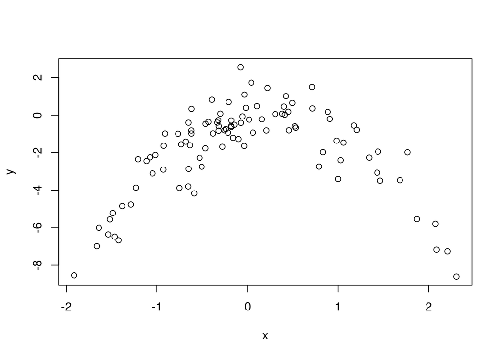

  ```r
    plot(x,y)
  ```

  - There is non-linear(quadratic) relation between x and y. x has values between -2 and 2.4 and y hass between -8.7 and 2.6
- 3c.
  - i

  ```r
    xydat=data.frame(y,x)

    set.seed(1)
    glm.fit=glm(y~x, data=xydat)
    cv.err=cv.glm(xydat,glm.fit)
    cv.err$delta[1]
  ```

  ```
  ## [1] 5.890979
  ```

  - ii

  ```r
    glm.fit=glm(y~poly(x,2), data=xydat)
    cv.err=cv.glm(xydat,glm.fit)
    cv.err$delta[1]
  ```

  ```
  ## [1] 1.086596
  ```

  - iii

  ```r
    glm.fit=glm(y~poly(x,3), data=xydat)
    cv.err=cv.glm(xydat,glm.fit)
    cv.err$delta[1]
  ```

  ```
  ## [1] 1.102585
  ```

  - iv

  ```r
    glm.fit=glm(y~poly(x,4), data=xydat)
    cv.err=cv.glm(xydat,glm.fit)
    cv.err$delta[1]
  ```

  ```
  ## [1] 1.114772
  ```

- 3d.

  ```r
    set.seed(2)
    glm.fit=glm(y~x, data=xydat)
    cv.err=cv.glm(xydat,glm.fit)
    cv.err$delta[1]
  ```

  ```
  ## [1] 5.890979
  ```

  ```r
    glm.fit=glm(y~poly(x,2), data=xydat)
    cv.err=cv.glm(xydat,glm.fit)
    cv.err$delta[1]
  ```

  ```
  ## [1] 1.086596
  ```

  ```r
    glm.fit=glm(y~poly(x,3), data=xydat)
    cv.err=cv.glm(xydat,glm.fit)
    cv.err$delta[1]
  ```

  ```
  ## [1] 1.102585
  ```

  ```r
    glm.fit=glm(y~poly(x,4), data=xydat)
    cv.err=cv.glm(xydat,glm.fit)
    cv.err$delta[1]
  ```

  ```
  ## [1] 1.114772
  ```

  - Yes, the results are same as in part 3c. This is expected because we are running LOOCV on the full set of data and in both cases all ‘n-1’ subsets are evaluated.
- 3e. Quadratic model has the lowet error (1.0866). This is expected because true model is quadratic as well.
- 3f.

  ```r
    summary(glm.fit)
  ```

  ```
  ##
  ## Call:
  ## glm(formula = y ~ poly(x, 4), data = xydat)
  ##
  ## Deviance Residuals:
  ##     Min       1Q   Median       3Q      Max
  ## -2.8914  -0.5244   0.0749   0.5932   2.7796
  ##
  ## Coefficients:
  ##             Estimate Std. Error t value Pr(>|t|)
  ## (Intercept)  -1.8277     0.1041 -17.549   <2e-16 ***
  ## poly(x, 4)1   2.3164     1.0415   2.224   0.0285 *
  ## poly(x, 4)2 -21.0586     1.0415 -20.220   <2e-16 ***
  ## poly(x, 4)3  -0.3048     1.0415  -0.293   0.7704
  ## poly(x, 4)4  -0.4926     1.0415  -0.473   0.6373
  ## ---
  ## Signif. codes:  0 '***' 0.001 '**' 0.01 '*' 0.05 '.' 0.1 ' ' 1
  ##
  ## (Dispersion parameter for gaussian family taken to be 1.084654)
  ##
  ##     Null deviance: 552.21  on 99  degrees of freedom
  ## Residual deviance: 103.04  on 95  degrees of freedom
  ## AIC: 298.78
  ##
  ## Number of Fisher Scoring iterations: 2
  ```

  - In all trials in Part(c), the t-value for the coefficients of linear and quadratic terms are high (and p values are <0.05) indicating that they fit with least error. Yes these align with LOOCV as we found the lowest error in the quadratic model.

# Q4

- 4a.

  ```r
    library(MASS)
    attach(Boston)
    set.seed(1)
    mean(medv)
  ```

  ```
  ## [1] 22.53281
  ```

- 4b.

  ```r
     sd(medv)/sqrt(length(medv))
  ```

  ```
  ## [1] 0.4088611
  ```

- 4c.

  ```r
  set.seed(1)
  boot.fn2 = function(inputdata,index){
  Boston_temp=inputdata[index,]
  return (mean(Boston_temp$medv))
    }

    boot(data=Boston, statistic = boot.fn2, R=1000)
  ```

  ```
  ##
  ## ORDINARY NONPARAMETRIC BOOTSTRAP
  ##
  ##
  ## Call:
  ## boot(data = Boston, statistic = boot.fn2, R = 1000)
  ##
  ##
  ## Bootstrap Statistics :
  ##     original      bias    std. error
  ## t1* 22.53281 0.008517589   0.4119374
  ```

  - Standard Error of Mean from (b) was 0.409 and answer from bootstrap is 0.412. So the answer are very close (within 0.003) to each other
- 4d.

  ```r
    t.test(Boston$medv)
  ```

  ```
  ##
  ##  One Sample t-test
  ##
  ## data:  Boston$medv
  ## t = 55.111, df = 505, p-value < 2.2e-16
  ## alternative hypothesis: true mean is not equal to 0
  ## 95 percent confidence interval:
  ##  21.72953 23.33608
  ## sample estimates:
  ## mean of x
  ##  22.53281
  ```

  ```r
    print(paste0("95% confidence from t.test is between 21.729 and 23.336"))
  ```

  ```
  ## [1] "95% confidence from t.test is between 21.729 and 23.336"
  ```

  ```r
    print(paste0("95% confidence interval from Bootstrap is between ", 22.532-2*0.412," and ", 22.532+2*0.412))
  ```

  ```
  ## [1] "95% confidence interval from Bootstrap is between 21.708 and 23.356"
  ```

  ```r
    median(medv)
  ```

  ```
  ## [1] 21.2
  ```

- 4f.

  ```r
  set.seed(1)
  bootmedian.fn = function(inputdata,index){
  Boston_temp=inputdata[index,]
  return (median(Boston_temp$medv))
    }

  boot(data=Boston, statistic = bootmedian.fn, R=1000)
  ```

  ```
  ##
  ## ORDINARY NONPARAMETRIC BOOTSTRAP
  ##
  ##
  ## Call:
  ## boot(data = Boston, statistic = bootmedian.fn, R = 1000)
  ##
  ##
  ## Bootstrap Statistics :
  ##     original   bias    std. error
  ## t1*     21.2 -0.01615   0.3801002
  ```

  ```r
    quantile(medv,c(0.1))
  ```

  ```
  ##   10%
  ## 12.75
  ```

- 4h

  ```r
  set.seed(1)
  boot_1Quantile.fn = function(inputdata,index){
  Boston_temp=inputdata[index,]
  return (quantile(Boston_temp$medv,c(0.1)))
    }

  boot(data=Boston, statistic = boot_1Quantile.fn, R=1000)
  ```

  ```
  ##
  ## ORDINARY NONPARAMETRIC BOOTSTRAP
  ##
  ##
  ## Call:
  ## boot(data = Boston, statistic = boot_1Quantile.fn, R = 1000)
  ##
  ##
  ## Bootstrap Statistics :
  ##     original  bias    std. error
  ## t1*    12.75 0.01005    0.505056
  ```

  - Using bootstrap to get standard error of 10th percentile gives a value of 0.505 which is very small. With 95% confidence we can say that the true 10th percentile is between 11.74 and 13.76

# Q5

- 5.1

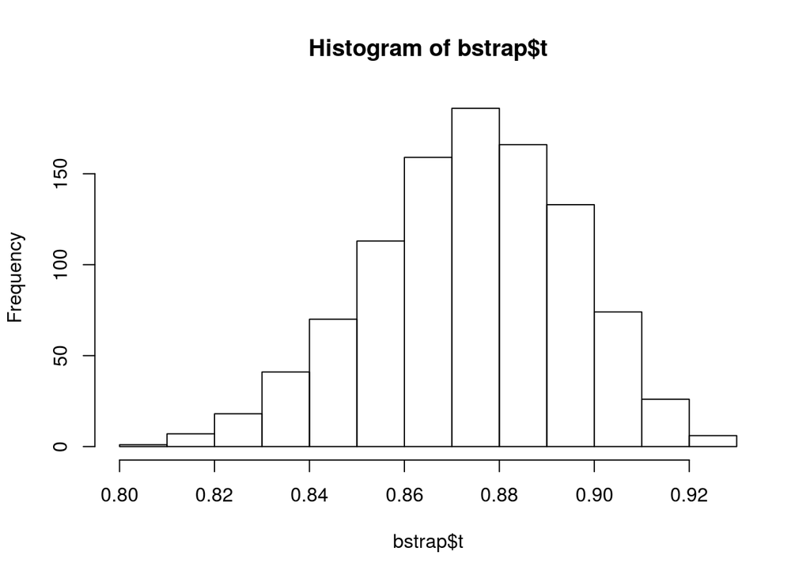

  ```r
    set.seed(1)
    library(boot)
    attach(USArrests)
    boot_pca.fn = function(input, index){
    temp_input=input[index,]
    pca_set=prcomp(temp_input,scale=TRUE)
    pca_var=pca_set$sdev^2
    prop_Var=(pca_var[1]+pca_var[2])/sum(pca_var)
    return(prop_Var)
    }

   bstrap= boot(data=USArrests, statistic = boot_pca.fn, R=1000)
   hist(bstrap$t)
  ```

- 5.2 Standard Error=0.0213

  ```r
  print(paste0("95% confidence interval for proportion of variance explained by first 2 components is ", 0.8675-2*0.0213," and ", 0.8675+2*0.0213, " or between 82.5% to 91.1%"))
  ```

  ```
  ## [1] "95% confidence interval for proportion of variance explained by first 2 components is 0.8249 and 0.9101 or between 82.5% to 91.1%"
  ```

- 5.3

  ```r
    boot_pca2.fn = function(input, index){
    temp_input=input[index,]
    pca_set=prcomp(temp_input,scale=TRUE)
    pca_pc1=pca_set$rotation[,1]
    return(pca_pc1)
  }

  boot(data=USArrests, statistic = boot_pca2.fn, R=1000)
  ```

  ```
  ##
  ## ORDINARY NONPARAMETRIC BOOTSTRAP
  ##
  ##
  ## Call:
  ## boot(data = USArrests, statistic = boot_pca2.fn, R = 1000)
  ##
  ##
  ## Bootstrap Statistics :
  ##       original    bias    std. error
  ## t1* -0.5358995 0.5751711   0.5367148
  ## t2* -0.5831836 0.6253797   0.5812652
  ## t3* -0.2781909 0.2922925   0.2851274
  ## t4* -0.5434321 0.5817628   0.5373784
  ```

- 5.4

  ```r
    runbstrap=function(inp_data){
      boot_pca3.fn = function(input, index){
        temp_input=input[index,]
        pca_set=prcomp(temp_input,scale=TRUE)
        v=sign(max(abs(pca_set$rotation[,1])))
        pca_signpc1=v*pca_set$rotation[,1]
        return(pca_signpc1)
      }

      bstrap=boot(data=inp_data, statistic = boot_pca2.fn, R=1000)

      boxplot(bstrap$t)
    }
  ```

- 5.5

  ```r
    runbstrap(USArrests)
  ```

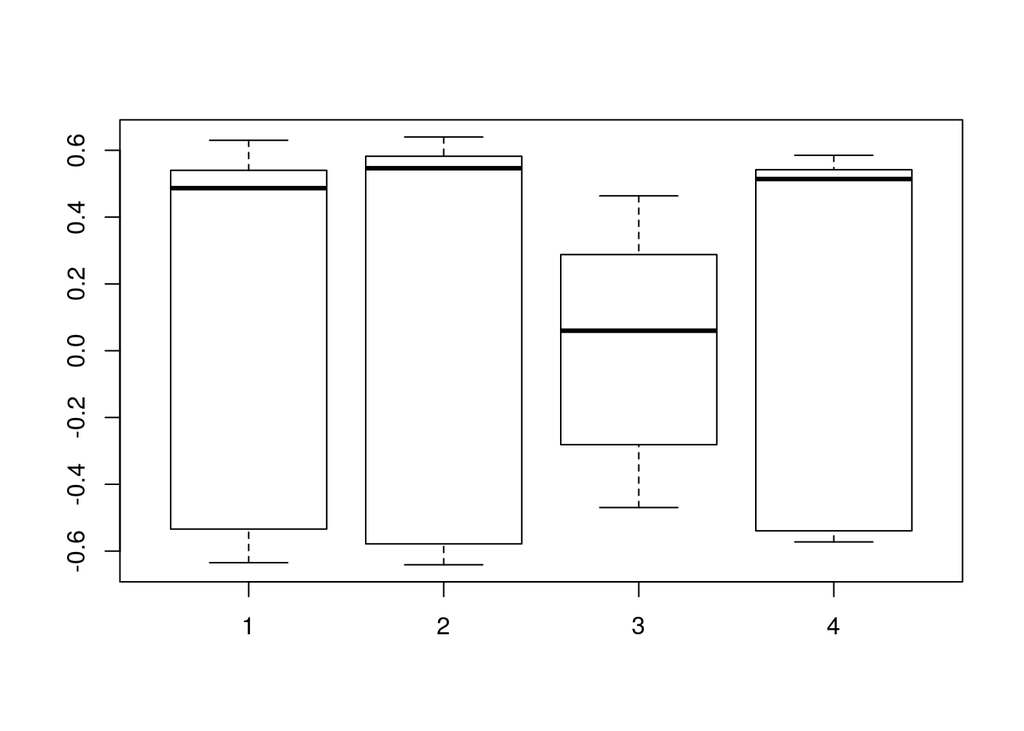

- 5.6